# *In vitro* expression - Nipah Virus Vaccine Concept

# 1 Case Overview

# 2 Project Overview

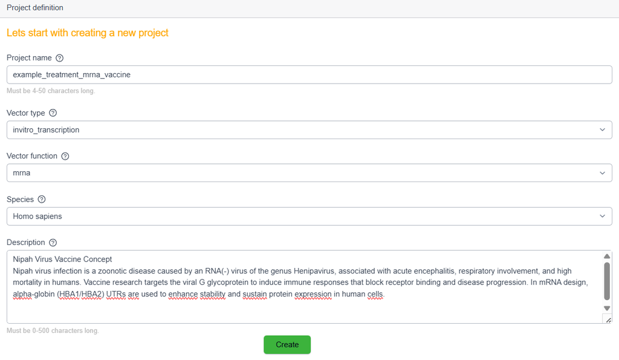

# 3 Design Workflow

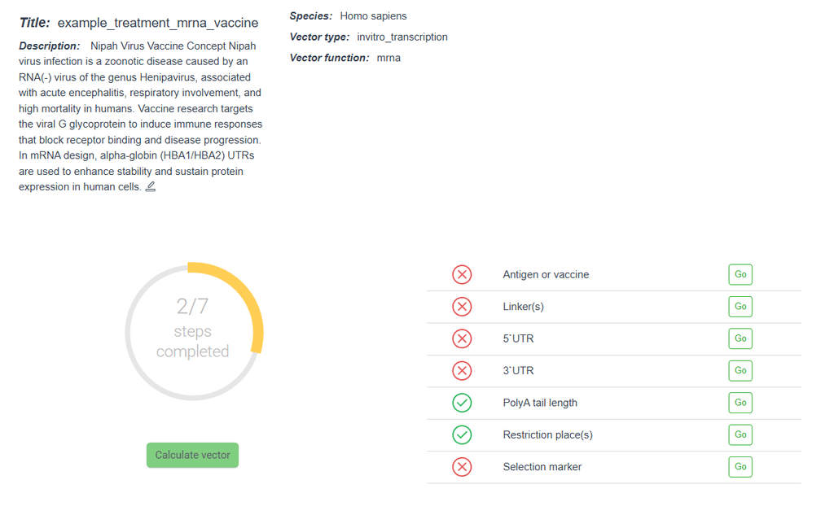

# 4 Antigene Selection

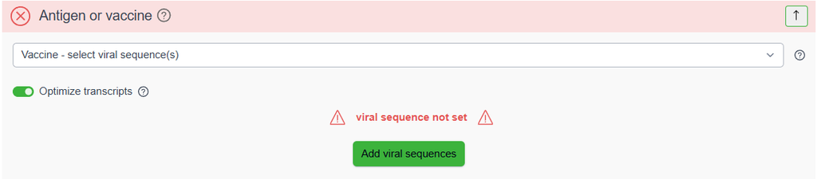

⬇

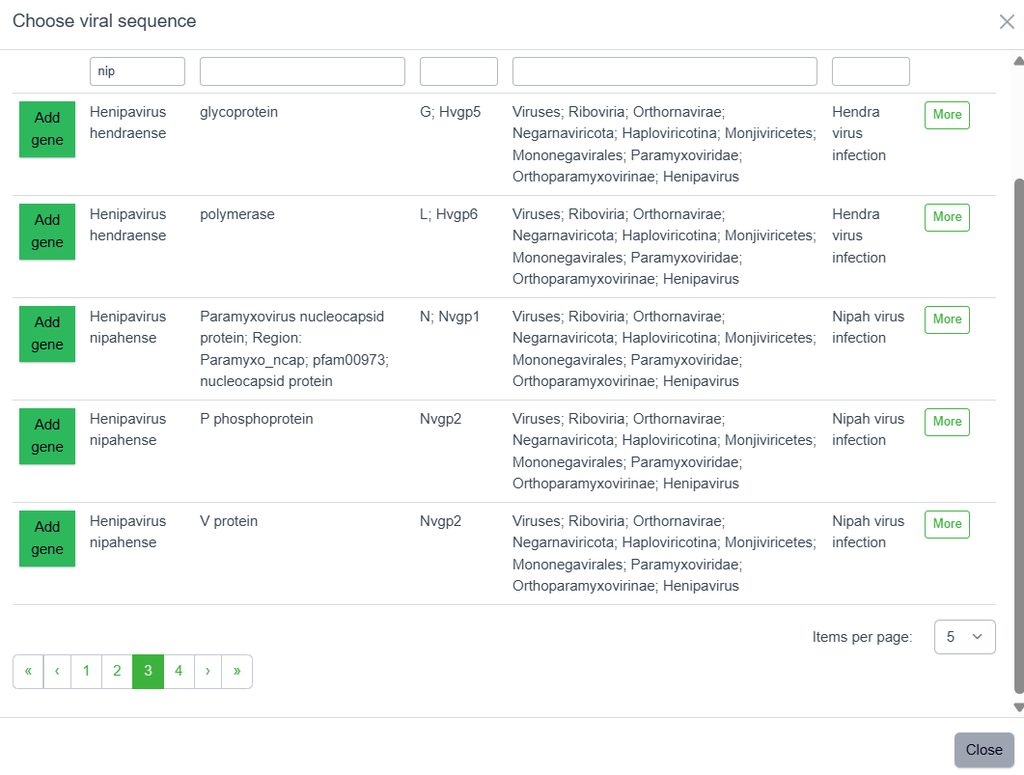

⬇

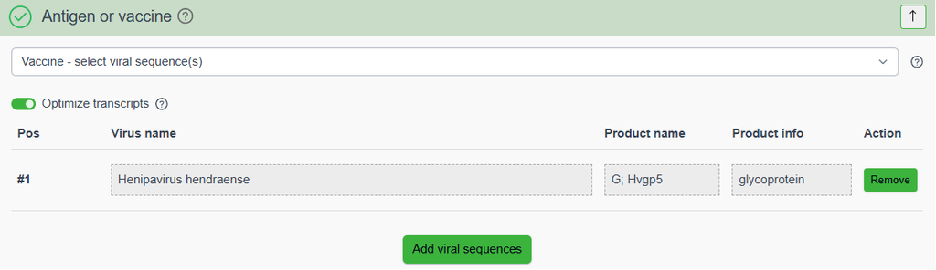

# 5 Linker Selection

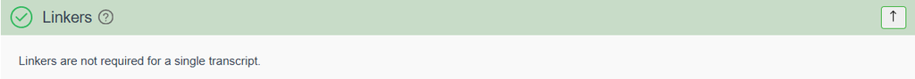

# 6 5’UTR Selection

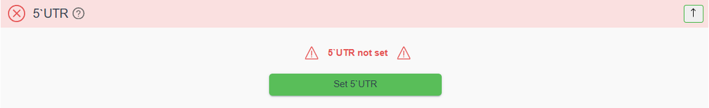

⬇

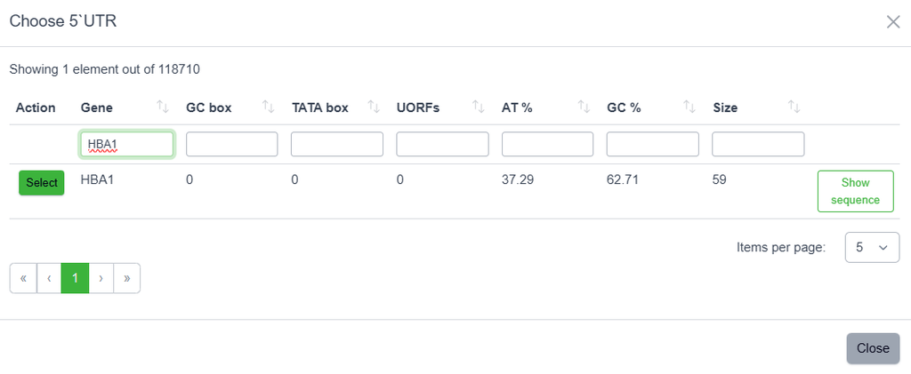

⬇

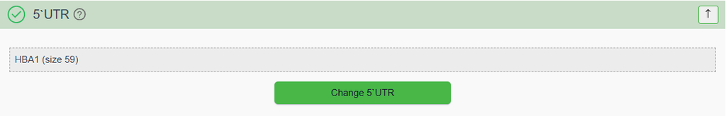

# 7 3’UTR Selection

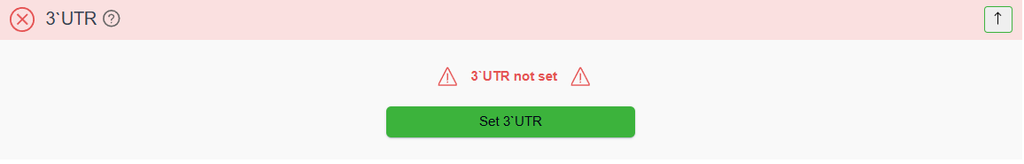

⬇

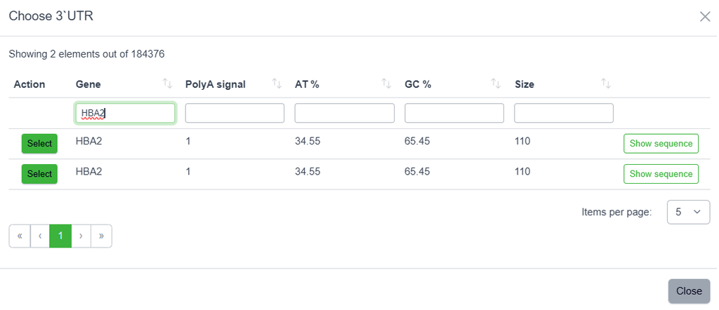

⬇

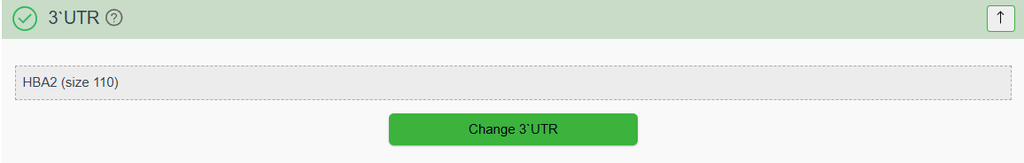

# 8 Polyadenylation Length

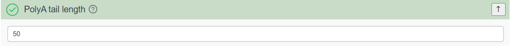

# 9 Restriction Places for Remove

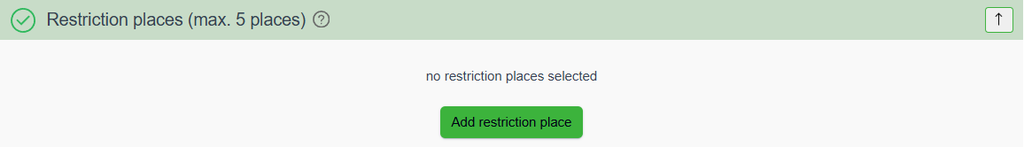

# 10 Selection Marker

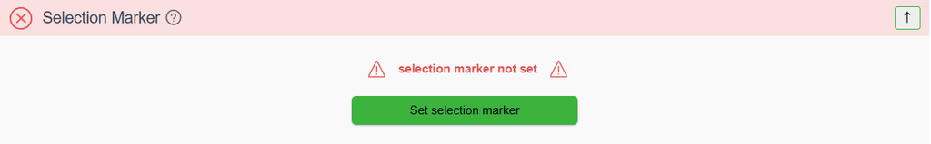

⬇

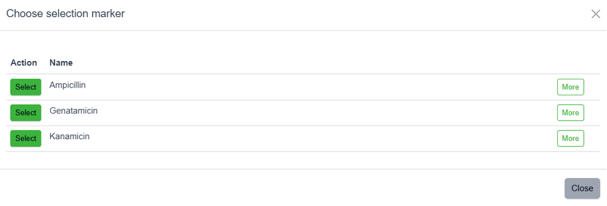

⬇

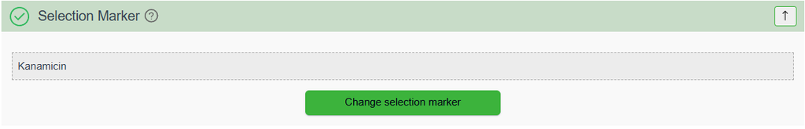

# 11 Calculations

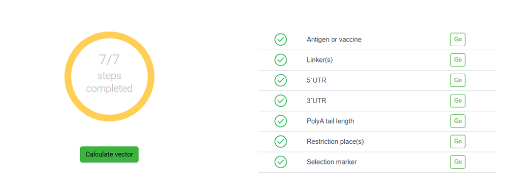

⬇

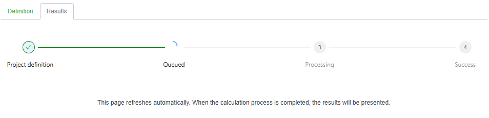

⬇

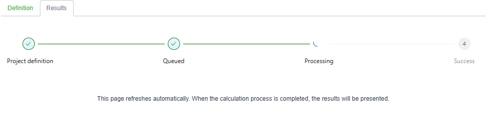

⬇

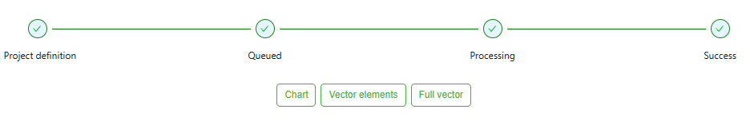

# 12 Results

## 12.1 Graphical Map of the Vector

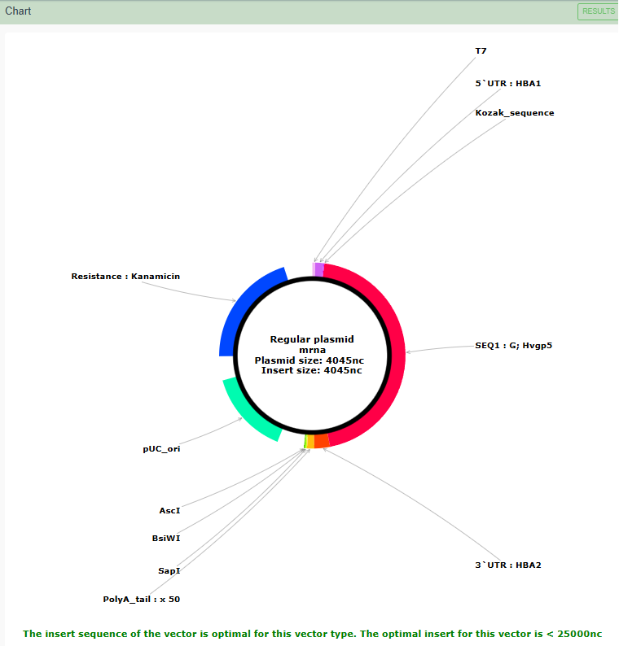

## 12.2 FASTA Representation (Segmented)

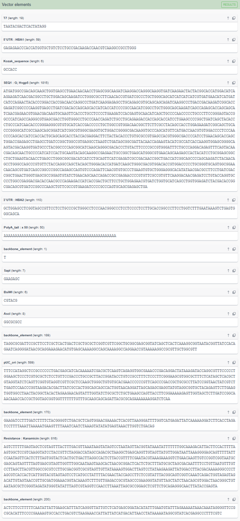

## 12.3 FASTA Representation (Full Sequence)

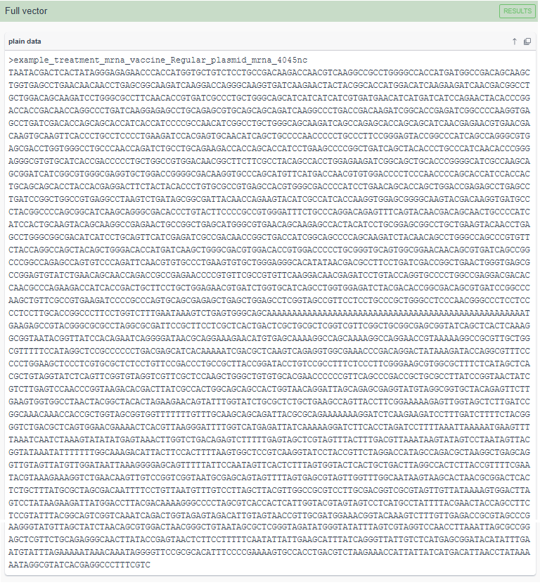

# 13 Disclaimer

The designed therapeutic compounds presented here are solely the result of *in silico* analyses conducted using available databases, computational models, and template-based design approaches.

It should be emphasized that findings obtained through *in silico* methods are predictive in nature and therefore require further experimental validation. Critical confirmation of their actual efficacy, safety, and biological relevance must be achieved through *in vitro* studies, followed by *in vivo* investigations.

Only comprehensive experimental verification can enable a reliable assessment of the true therapeutic potential of the proposed compounds.